# Report Metrics for Collections from an Institution

David Jennings, iDigBio Project Manager[^1]

Created on 2021-Mar-30. Last modified on 2021-Apr-28.

# Objective

In this use case, we explore a solution for how to [Report metrics for collections within an institution](https://biodiversity-specimen-data.github.io/specimen-data-use-case/use-case/report-institution-metrics.html) using the [iDigBio API](https://github.com/iDigBio/idigbio-search-api/wiki). iDigBio began collecting statistics for each recordset contained in the [iDigBio Portal](https://www.idigbio.org/portal) in January 2015, and these statistics are available in tabular format on the particular recordset’s Data Use tab. However, these data can also be accessed via the iDigBio API to facilitate aggregation for reporting purposes.

# Scenario

For this solution, let’s assume that the Director of the [University of Florida’s](http://www.ufl.edu/) [Florida Museum of Natural History](https://www.floridamuseum.ufl.edu/) has asked us to report metrics on the collections held by the university based on the data available in iDigBio.

# Let’s get things set up

## First, we need to load a helper package

The iDigBio API returns data in JSON (JavaScript Object Notation) format, so we’ll use the [`jsonlite`](https://cran.r-project.org/web/packages/jsonlite/index.html) package to help us retrieve and parse the data. Make sure you install the package if you haven’t already using the command `install.packages("jsonlite")`.

```r
library(jsonlite)
```

## Third, remember that we need to encode certain characters in URLs

When making the API calls, we will need to encode the “unsafe” characters in the URLs. The following are the most common characters in the API calls that should be encoded:

| Character | Encoding | Description |
| --- | --- | --- |
| space | %20 | Spaces separate words in JSON strings |
| " | %22 | Quotation marks enclose strings in JSON |
| { | %7B | Left brace indicates the start of a JSON object |
| } | %7D | Right brace indicates the end of a JSON object |
| [ | %5B | Left bracket indicates the start of a JSON array |
| ] | %5D | Right bracket indicates the end of a JSON array |
| , | %2C | Commas separate items in JSON arrays |

## And, fourth, let’s establish a few parameters for the reporting

```r
# Time interval for statistics as "year", "month", "week", or "day"
## NOTE: be wise in your selection because week and day, in particular, will produce extremely large result sets
dateInterval <- "year"

# Start date for statistics in "YYYY-MM-DD" format
## NOTE: we will default to the date that iDigBio started collecting statistics
minDate <- "2015-01-16"

# End date for statistics in "YYYY-MM-DD" format
## NOTE: we will default to the current system date
maxDate <- format(Sys.Date(), format="%Y-%m-%d")

# The number of values to return
## NOTE: this only applies to certain API calls, like Top-N Records
maxCount = 15

# The fields we are interested in for the Taxonomic Coverage
## NOTE: be wise in your selection because the data grows exponentially with each additional field
## Valid fields are listed at: https://github.com/iDigBio/idigbio-search-api/wiki/Index-Fields#record-query-fields
taxaFields = c("kingdom", "family")
```

# Okay, now we’re ready to identify the institutional recordsets

To gather the information for reporting, we need to know the identifiers (UUIDs) of each collection held by the university. We can manually determine this by searching through the [Data Publishers](https://www.idigbio.org/portal/publishers) on the iDigBio portal.

```r
# Institution name for use later in plot titles etc.
institution <- "University of Florida"

# Recordset UUIDs
instUUID <- c("bd7cfd55-bf55-46fc-878d-e6e11f574ccd", # University of Florida Herpetology
              "f9a33279-d6ba-41c7-a511-ef6adfcb6e20", # University of Florida Vertebrate Paleontology
              "781fd581-7b93-471e-a025-413e4bcd8491", # University of Florida Herbarium (FLAS)
              "1ba0bbad-28a7-4c50-8992-a028f79d1dc5", # University of Florida Invertebrate Paleontology
              "6bb853ab-e8ea-43b1-bd83-47318fc4c345", # UF Invertebrate Zoology
              "0e162e0a-bf3e-4710-9357-44258ca12abb", # UF Florida Museum Paleobotany
              "c38b867b-05f3-4733-802e-d8d2d3324f84", # UF FLMNH Ichthyology
              "2b76daad-10dc-4235-843e-dffad2424df7", # UF Florida Museum of Natural History Ornithology
              "48e1b8c1-91aa-4b87-8ca0-de1f81232eaf", # UF Florida Museum of Natural History Mammals
              "b3b89632-0a22-4532-a05b-6830d07542f7", # UF Environmental Archaeology North Midden Zooarchaeological Data
              "b293a647-5fb8-4b82-bf5b-571e7d6fad03", # UF Environmental Archaeology Tick Island Zooarchaeological Data
              "c02ce6fc-a2f3-497e-bc3c-0adce054db72", # UF Florida Archaeology Parnell Mound Site (8CO326), Feature 1 Zooarchaeological Data
              "fccc3c1d-d9df-4ffd-b7e1-1b9eb11f95b1", # University of Florida Herbarium
              "b5e5c781-765f-4981-af2a-c19c250e2cf0", # University of Florida Herbarium
              "1f2b44b8-8556-4d6e-8247-4611689551cf", # University of Florida Herbarium
              "e85a9948-9c9e-451d-9485-b2b4cb7b73d5", # University of Florida, Florida Museum of Natural History
              "6135420b-aac1-476e-bda5-e07ba8458662") # Repatriación de datos de los lepidópteros depositados en la Colección del McGuire Center for Lepidoptera and Biodiversity, Florida Museum of Natural History
```

As an aside, the recommended maximum “safe” length of internet URLs is around 2,000 characters. As a result, for the queries in this notebook, we could include a maximum of about 40-45 recordset UUIDs.

# Let’s get the total number of specimen and media records

Two of the simplest metrics we can report are the total counts of specimen records and media records contained in the iDigBio Portal for the recordsets in question. For this, we will make calls to the [Record Count](https://github.com/iDigBio/idigbio-search-api/wiki#record-count) and [Media count](https://github.com/iDigBio/idigbio-search-api/wiki#media-count) API endpoints.

```r
# Initialize the API URLs
sURL <- "https://search.idigbio.org/v2/summary/count/records/"
mURL <- "https://search.idigbio.org/v2/summary/count/media/"

# Add the UUIDs as an array []; encase each UUID in quotation marks and separate with commas
sURL <- paste(sURL, "?rq=%7B%22recordset%22:%5B",gsub("\"","%22",paste(dQuote(unlist(instUUID),FALSE),collapse="%2C")),"%5D%7D", sep="")
mURL <- paste(mURL, "?rq=%7B%22recordset%22:%5B",gsub("\"","%22",paste(dQuote(unlist(instUUID),FALSE),collapse="%2C")),"%5D%7D", sep="")

# Get the total number of specimen records
sCount <- jsonlite::read_json(sURL)

# Get the total number of media records
mCount <- jsonlite::read_json(mURL)
```

There are **2,267,110 specimen records** with **221,370 associated media records** in iDigBio for **University of Florida**.

# Now, let’s take a look at the data ingested in iDigBio over time

To examine the data ingestion statistics over time, we will make calls to the [Stats](https://github.com/iDigBio/idigbio-search-api/wiki#stats) API endpoint.

```r
# Initialize the API URL
baseiURL <- paste("https://search.idigbio.org/v2/summary/stats/api/", "?dateInterval=", dateInterval, "&minDate=", minDate, "&maxDate=", maxDate, sep="")

# Now add the UUIDs, but note that this API endpoint does not allow `rq` based searches
## So, we need to create a list of URLs (one URL for each recordset) and then combine the results later
iURL <- lapply(instUUID, function(x) paste(baseiURL, "&recordset=", x, sep=""))

# Get the ingestion statistics for each recordset
ingestStatsRAW <- lapply(iURL, function(x) jsonlite::read_json(x))
```

When we retrieve the ingestion data from the API, it comes in as a list of recordsets with the basic structure: `dates` > `YYYY-MM-DD` > `UUID` > `Metric`. So, we need to manipulate and aggregate this information into a data frame of dates and counts for each metric, which will facilitate plotting.

```r
# Flatten the list structure and convert to a data frame
ingestStats <- as.data.frame(unlist(ingestStatsRAW))

# Convert the row names into a new column
ingestStats <- cbind(rownames(ingestStats), data.frame(ingestStats, row.names=NULL))

# Rename the columns to make the next few steps easier
colnames(ingestStats)<- c("mashup","Count")

# Split the first column into separate columns
ingestStats <- cbind(data.frame(do.call("rbind", strsplit(as.character(ingestStats$mashup), ".", fixed = TRUE))), ingestStats$Count)
ingestStats <- subset(ingestStats, select = c("X2", "X3", "X4","ingestStats$Count"))

# Rename the columns to make sense
colnames(ingestStats)<- c("Date", "Recordset", "Metric", "Count")

# Convert the dates from string to date format
ingestStats$Date <- as.Date(substr(ingestStats$Date, 1, 10))

# Generate cumulative sums by date by metrics
ingestMetrics <- aggregate(Count ~ Date + Metric, data = ingestStats, FUN = sum)
```

Now let’s plot the data ingestion metrics over time:

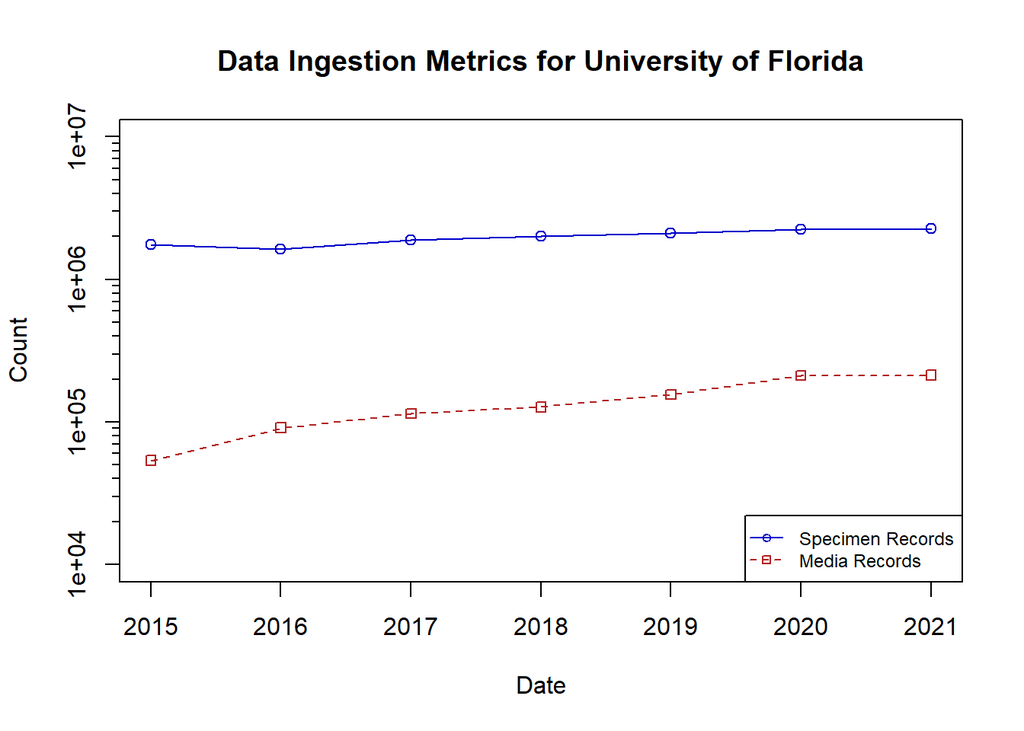

```r
# Figure out the data range to determine location of minor log tick marks
## Magic for minor ticks: https://stackoverflow.com/questions/5821763/logarithmic-y-axis-tick-marks-in-r-plot-or-ggplot2
magRng <- floor(log10(range(ingestMetrics$Count)+1))        # Upper+lower 10^x magnitudes with zero protection
pwr <- seq(magRng[1], magRng[2]+1)                          # Adjust the 10^x range for display
ticksat <- as.vector(sapply(pwr, function(p) (1:10)*10^p))  # Locations of minor log tick marks

# Start by plotting the specimen records
with(subset(ingestMetrics, Metric == "records"), {
  plot(Date, Count, type="o", pch=21, lty=1, col="mediumblue", xlab="Date", ylab="Count", main=paste("Data Ingestion Metrics for", institution), ylim=c(10^magRng[1], 10^(magRng[2]+1)), log="y", yaxt="n")
  axis(2, 10^pwr)
  axis(2, ticksat, labels=NA, tcl=-0.25, lwd=0, lwd.ticks=1)
})

# Now add the media records
with(subset(ingestMetrics, Metric == "mediarecords"), {
  lines(Date, Count, type="o", pch=22, lty=2,  col="firebrick")
})

# Finally, add a legend
legend("bottomright", legend=c("Specimen Records", "Media Records"), pch=21:22, lty=1:2, col=c("mediumblue", "firebrick"), bg="transparent", cex=0.75)
```

# Let’s see how the institution’s data has been used over time

iDigBio’s data use statistics are provided via the following metrics:

| Metric | Definition |
| --- | --- |
| Search | Total number of records that have matched a search query |
| Seen | Total number of records that have been displayed to users in a browser window |
| Download | Total number of records that have been downloaded by users |
| Records Viewed | Total number of specimen records that have been directly viewed by users |
| Media Viewed | Total number of media records that have been directly viewed by users |
| Search Count | Total number of search events that have been executed by users |
| Download Count | Total number of download events that have been executed by users |

Similar to the data ingestion metrics, the data use metrics arrive as a list of recordsets with the basic structure: `dates` > `YYYY-MM-DD` > `UUID` > `Metric`, so we’ll follow the same procedure as above to facilitate plotting.

```r
# Initialize the API URL
baseuURL <- paste("https://search.idigbio.org/v2/summary/stats/search/", "?dateInterval=", dateInterval, "&minDate=", minDate, "&maxDate=", maxDate, sep="")

# Now add the UUIDs but note that this API endpoint does not allow `rq` based searches
## So, instead, we will to create a list of URLs (one URL for each recordset) and then combine the results later
uURL <- lapply(instUUID, function(x) paste(baseuURL, "&recordset=", x, sep=""))

# Get the data use statistics for each recordset
useStatsRAW <- lapply(uURL, function(x) jsonlite::read_json(x))


# Manipulate the data to facilitate plotting

## Flatten the list structure and convert to a data frame
useStats <- as.data.frame(unlist(useStatsRAW))

## Convert the row names into a new column
useStats <- cbind(rownames(useStats), data.frame(useStats, row.names=NULL))

## Rename the columns to make the next few steps easier
colnames(useStats)<- c("mashup","Count")

## Split the first column into separate columns
useStats <- cbind(data.frame(do.call("rbind", strsplit(as.character(useStats$mashup), ".", fixed = TRUE))), useStats$Count)
useStats <- subset(useStats, select = c("X2", "X3", "X4","useStats$Count"))

## Rename the columns to make sense
colnames(useStats)<- c("Date", "Recordset", "Metric", "Count")

## Convert the dates from string to date format
useStats$Date <- as.Date(substr(useStats$Date, 1, 10))

## Generate sums by date by metrics
useMetrics <- aggregate(Count ~ Date + Metric, data = useStats, FUN = sum)
```

## To start, let’s take a look at the number of search events compared with the number of download events

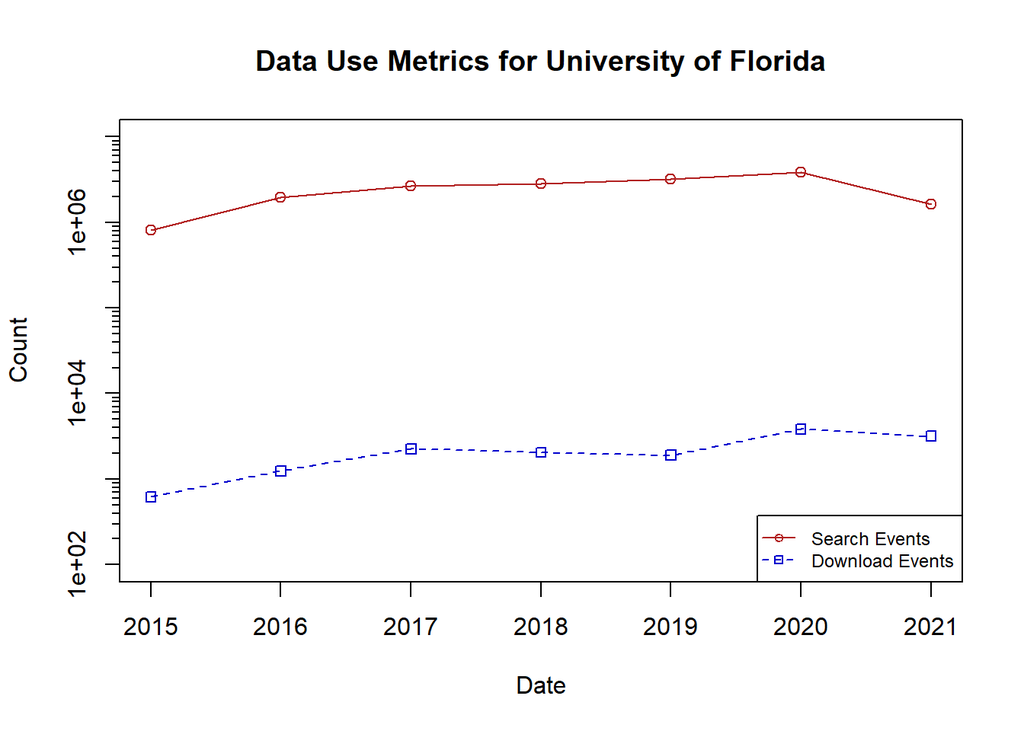

```r
# Figure out the data range to determine location of minor log tick marks
magRng <- floor(log10(with(subset(useMetrics, subset = Metric %in% c("search_count", "download_count")), {range(Count)})+1))
pwr <- seq(magRng[1], magRng[2]+1)
ticksat <- as.vector(sapply(pwr, function(p) (1:10)*10^p))

# Start by plotting the search events
with(subset(useMetrics, Metric == "search_count"), {
  plot(Date, Count, type="o", pch=21, lty=1, col="firebrick", xlab="Date", ylab="Count", main=paste("Data Use Metrics for", institution), ylim=c(10^magRng[1], 10^(magRng[2]+1)), log="y", yaxt="n")
  axis(2, 10^pwr)
  axis(2, ticksat, labels=NA, tcl=-0.25, lwd=0, lwd.ticks=1)
})

# Now add the download events
with(subset(useMetrics, Metric == "download_count"), {
  lines(Date, Count, type="o", pch=22, lty=2,  col="mediumblue")
})

# Finally, add a legend
legend("bottomright", legend=c("Search Events", "Download Events"), pch=21:22, lty=1:2, col=c("firebrick", "mediumblue"), bg="transparent", cex=0.75)
```

## Next, let’s look at the number of records downloaded as compared with the numbers of records and media directly viewed

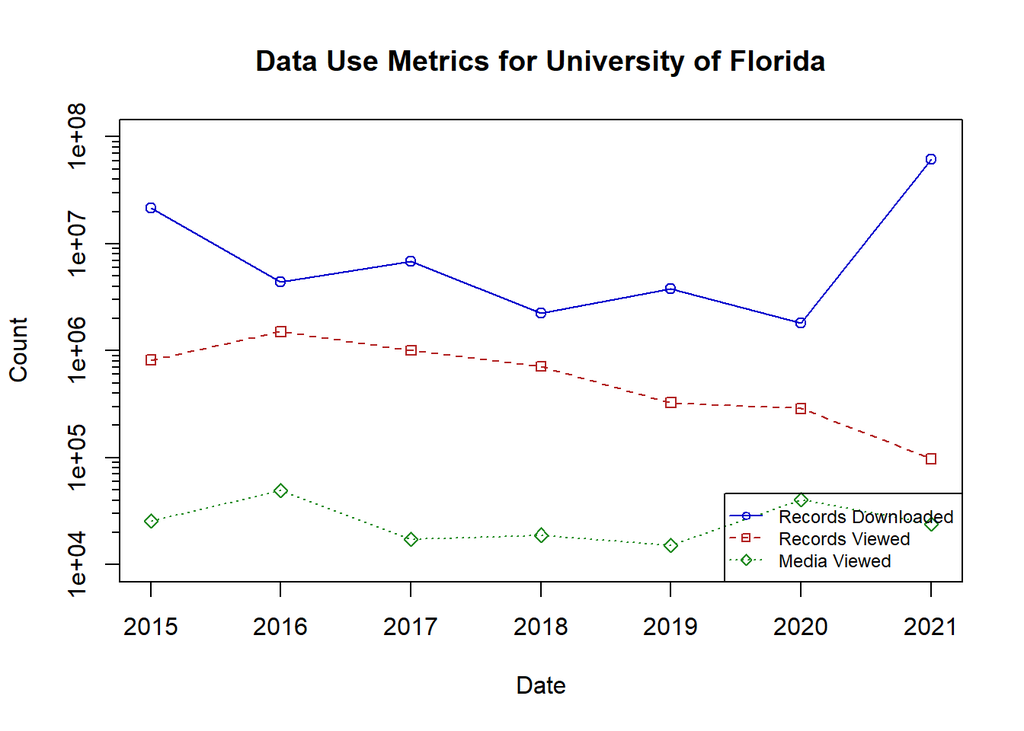

```r
# Figure out the data range to determine location of minor log tick marks
magRng <- floor(log10(with(subset(useMetrics, subset = Metric %in% c("download", "viewed_records", "viewed_media")), {range(Count)})+1))
pwr <- seq(magRng[1], magRng[2]+1)
ticksat <- as.vector(sapply(pwr, function(p) (1:10)*10^p))

# Start by plotting the downloaded records
with(subset(useMetrics, Metric == "download"), {
  plot(Date, Count, type="o", pch=21, lty=1, col="mediumblue", xlab="Date", ylab="Count", main=paste("Data Use Metrics for", institution), ylim=c(10^magRng[1], 10^(magRng[2]+1)), log="y", yaxt="n")
  axis(2, 10^pwr)
  axis(2, ticksat, labels=NA, tcl=-0.25, lwd=0, lwd.ticks=1)
})

# Now add records viewed
with(subset(useMetrics, Metric == "viewed_records"), {
  lines(Date, Count, type="o", pch=22, lty=2,  col="firebrick")
})

# Now add media viewed
with(subset(useMetrics, Metric == "viewed_media"), {
  lines(Date, Count, type="o", pch=23, lty=3,  col="forestgreen")
})

# Finally, add a legend
legend("bottomright", legend=c("Records Downloaded", "Records Viewed", "Media Viewed"), pch=21:23, lty=1:3, col=c("mediumblue", "firebrick", "forestgreen"), bg="transparent", cex=0.75)
```

## Can we see other trends through ratios of one metric to another metric?

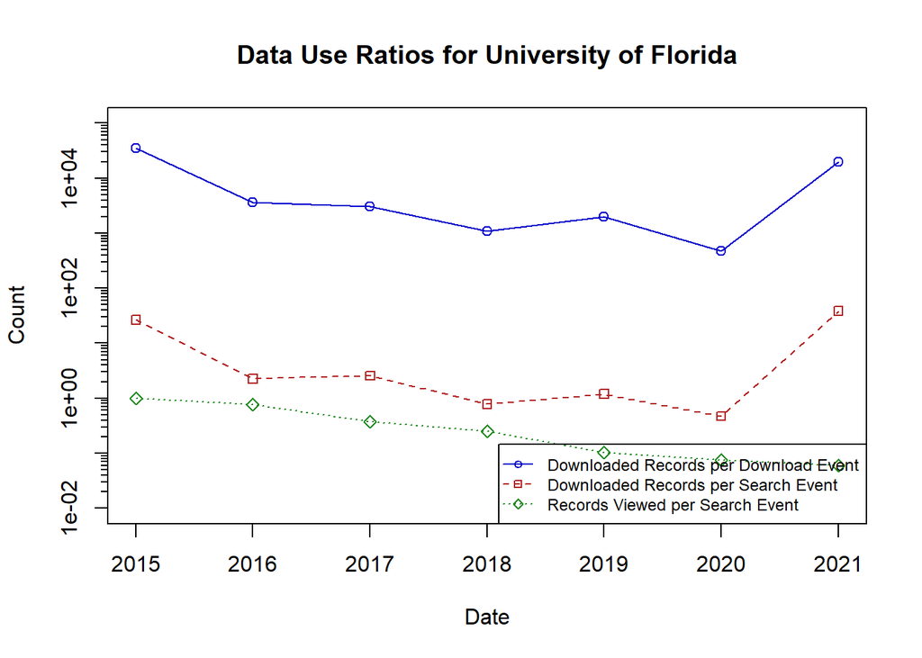

```r
# The average number of records downloaded per download event
dlRatio <- cbind(subset(useMetrics, Metric == "download")["Date"], subset(useMetrics, Metric == "download")["Count"] / subset(useMetrics, Metric == "download_count")["Count"])

# The average number of records downloaded per search event
sdRatio <- cbind(subset(useMetrics, Metric == "download")["Date"], subset(useMetrics, Metric == "download")["Count"] / subset(useMetrics, Metric == "search_count")["Count"])

# The average number of records viewed per search event
vsRatio <- cbind(subset(useMetrics, Metric == "search_count")["Date"], subset(useMetrics, Metric == "viewed_records")["Count"] / subset(useMetrics, Metric == "search_count")["Count"])


# Plot the ratios

## Figure out the data range to determine location of minor log tick marks
magRng <- floor(log10(range(dlRatio$Count, sdRatio$Count, vsRatio$Count)))
pwr <- seq(magRng[1], magRng[2]+1)
ticksat <- as.vector(sapply(pwr, function(p) (1:10)*10^p))

## Start by plotting the download ratio
with(dlRatio, {
  plot(Date, Count, type="o", pch=21, lty=1, col="mediumblue", xlab="Date", ylab="Count", main=paste("Data Use Ratios for", institution), ylim=c(10^magRng[1], 10^(magRng[2]+1)), log="y", yaxt="n")
  axis(2, 10^pwr)
  axis(2, ticksat, labels=NA, tcl=-0.25, lwd=0, lwd.ticks=1)
})

## Now add the download-to-search ratio
with(sdRatio, {
  lines(Date, Count, type="o", pch=22, lty=2,  col="firebrick")
})

# Now add the viewed-to-search ratio
with(vsRatio, {
  lines(Date, Count, type="o", pch=23, lty=3,  col="forestgreen")
})

## Finally, add a legend
legend("bottomright", legend=c("Downloaded Records per Download Event", "Downloaded Records per Search Event", "Records Viewed per Search Event"), pch=21:23, lty=1:3, col=c("mediumblue", "firebrick", "forestgreen"), bg="transparent", cex=0.75)
```

# Let’s shift gears and look at the taxonomic coverage of the specimen and media records

For this examination, we will use the [Top-N Records](https://github.com/iDigBio/idigbio-search-api/wiki#top-n-records) API endpoint.

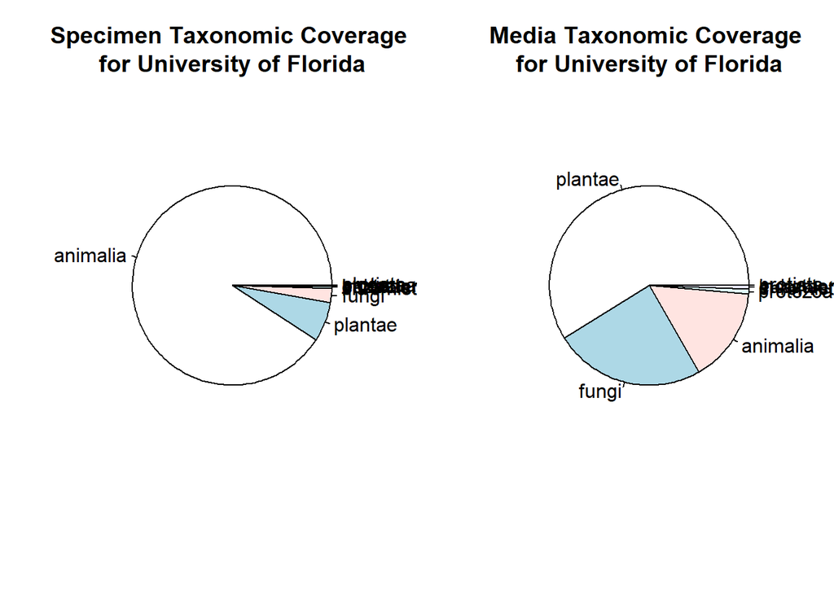

```r
# Initialize the API URL
## Note: specify the taxonomic fields as an array [], encase each field in quotation marks, and separate with commas
basetURL <- paste("https://search.idigbio.org/v2/summary/top/records/", "?top_fields=%5B", gsub("\"","%22",paste(dQuote(unlist(taxaFields),FALSE),collapse="%2C")), "%5D&count=", maxCount, sep="")

# Add the UUIDs as an array []; encase each UUID in quotation marks and separate with commas
## Note that we need two separate URLs (one for specimen records and another for specimens records with associated media)
stURL <- paste(basetURL, "&rq=%7B%22recordset%22:%5B",gsub("\"","%22",paste(dQuote(unlist(instUUID),FALSE),collapse="%2C")),"%5D%7D", sep="")
mtURL <- paste(basetURL, "&rq=%7B%22recordset%22:%5B",gsub("\"","%22",paste(dQuote(unlist(instUUID),FALSE),collapse="%2C")),"%5D,%22hasImage%22:true%7D", sep="")


# Get the taxonomic information
sTaxaRAW <- jsonlite::read_json(stURL)
mTaxaRAW <- jsonlite::read_json(mtURL)


# Manipulate the data to facilitate plotting

## Flatten the list structure and convert to a data frame
sTaxa <- as.data.frame(unlist(sTaxaRAW$kingdom))
mTaxa <- as.data.frame(unlist(mTaxaRAW$kingdom))

## Convert the row names into a new column
sTaxa <- cbind(rownames(sTaxa), data.frame(sTaxa, row.names=NULL))
mTaxa <- cbind(rownames(mTaxa), data.frame(mTaxa, row.names=NULL))

## Rename the columns to make the next few steps easier
colnames(sTaxa)<- c("mashup","Count")
colnames(mTaxa)<- c("mashup","Count")

## Split the first column into separate columns
sTaxa <- cbind(data.frame(do.call("rbind", strsplit(as.character(sTaxa$mashup), ".", fixed = TRUE))), sTaxa$Count)
sTaxa <- subset(sTaxa, select = c("X1", "X2", "X3","sTaxa$Count"))
mTaxa <- cbind(data.frame(do.call("rbind", strsplit(as.character(mTaxa$mashup), ".", fixed = TRUE))), mTaxa$Count)
mTaxa <- subset(mTaxa, select = c("X1", "X2", "X3","mTaxa$Count"))

## Rename the columns to make sense
colnames(sTaxa)<- c("Kingdom", "Key", "Family", "Count")
colnames(mTaxa)<- c("Kingdom", "Key", "Family", "Count")


# Plot the taxonomic coverage
par(mfrow=c(1,2))   # plot side by side
with(subset(sTaxa, Key == "itemCount"), {
  pie(Count, labels = Kingdom, main=paste("Specimen Taxonomic Coverage \nfor", institution))
})
with(subset(mTaxa, Key == "itemCount"), {
  pie(Count, labels = Kingdom, main=paste("Media Taxonomic Coverage \nfor", institution))
})
```

# Next, let’s look at the range of dates collected for the institution

For this one, we will use the [Date Histogram](https://github.com/iDigBio/idigbio-search-api/wiki#date-histogram) API endpoint.

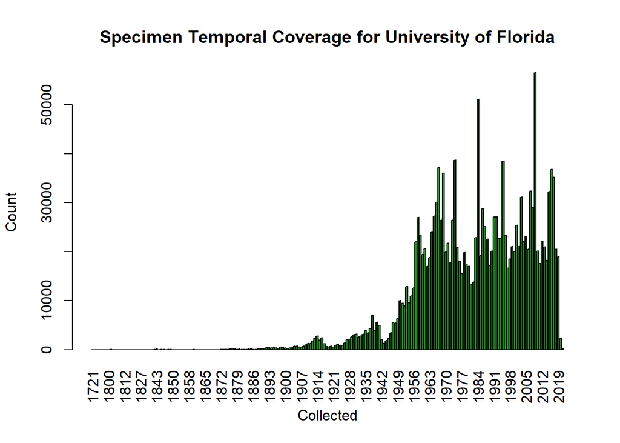

```r
# Initialize the API URL
tURL <- paste("https://search.idigbio.org/v2/summary/datehist", "?dateInterval=", dateInterval, sep="")

# Add the UUIDs as an array []; encase each UUID in quotation marks and separate with commas
tURL <- paste(tURL, "&rq=%7B%22recordset%22:%5B",gsub("\"","%22",paste(dQuote(unlist(instUUID),FALSE),collapse="%2C")),"%5D%7D", sep="")


# Get the information on date collected
sDateCollRAW <- jsonlite::read_json(tURL)


# Manipulate the data to facilitate plotting

## Flatten the list structure and convert to a data frame
sDateColl <- as.data.frame(unlist(sDateCollRAW$dates))

## Convert the row names into a new column
sDateColl <- cbind(rownames(sDateColl), data.frame(sDateColl, row.names=NULL))

## Rename the columns to make the next few steps easier
colnames(sDateColl)<- c("mashup","Count")

## Split the first column into separate columns
sDateColl <- cbind(data.frame(do.call("rbind", strsplit(as.character(sDateColl$mashup), ".", fixed = TRUE))), sDateColl$Count)
sDateColl <- subset(sDateColl, select = c("X1", "sDateColl$Count"))

## Rename the columns to make sense
colnames(sDateColl)<- c("Date", "Count")

## Convert the dates from string to date format
sDateColl$Date <- as.Date(substr(sDateColl$Date, 1, 10))

# Plot the temporal coverage
with(sDateColl, {
  barplot(Count, names.arg = format(Date, '%Y'), xlab="Collected", ylab="Count", main=paste("Specimen Temporal Coverage for", institution), las=3, col="forestgreen")
})
```

# Last, but not least, let’s look at the data quality flags applied to the data

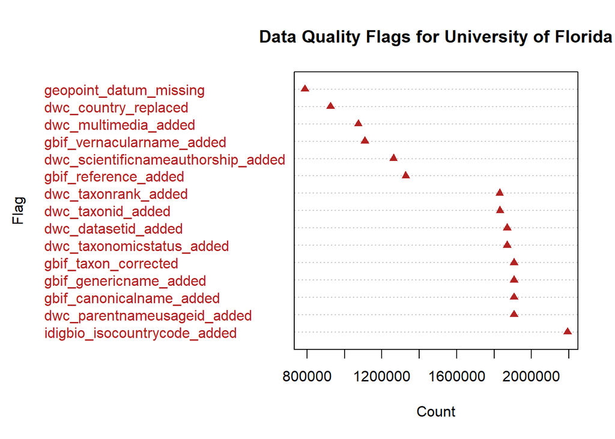

```r
# Initialize the API URL
fURL <- paste("https://search.idigbio.org/v2/summary/top/records/?top_fields=%22flags%22&count=", maxCount, sep="")

# Add the UUIDs as an array []; encase each UUID in quotation marks and separate with commas
fURL <- paste(fURL, "&rq=%7B%22recordset%22:%5B",gsub("\"","%22",paste(dQuote(unlist(instUUID),FALSE),collapse="%2C")),"%5D%7D", sep="")


# Get the top data quality flags
sFlagsRAW <- jsonlite::read_json(fURL)


# Manipulate the data to facilitate plotting

## Flatten the JSON structure and convert to a data frame
sFlags <- as.data.frame(unlist(sFlagsRAW$flags))

## Convert the row names into a new column
sFlags <- cbind(rownames(sFlags), data.frame(sFlags, row.names=NULL))

## Rename the columns to make the next few steps easier
colnames(sFlags)<- c("mashup","Count")

## Split the first column into separate columns
sFlags <- cbind(data.frame(do.call("rbind", strsplit(as.character(sFlags$mashup), ".", fixed = TRUE))), sFlags$Count)
sFlags <- subset(sFlags, select = c("X1", "sFlags$Count"))

## Rename the columns to make sense
colnames(sFlags)<- c("Flag", "Count")


# Plot the data quality flags
with(sFlags, {
  dotchart(Count, labels=Flag, pch=17, xlab="Count", ylab="Flag", main=paste("Data Quality Flags for", institution), col="firebrick")
})
```

[^1]: University of Florida, Florida Museum of Natural History, https://orcid.org/0000-0003-0520-6983